# Venezuelan dollar rate analysis

*Build a model that predicts future values of venezuelan dollar rates based on existing data*

## Author and purpose

This document is a work in progress made by Jose Wilhelm, a backend developer and data analyst; it will serve as a preliminary analysis for a much bigger project I'm working on. You can read more about me in my **[portfolio.](https://joselws.github.io/)**

### Caveat

This document is made to be perfectly read and understood whilst ignoring the technical details, just by focusing on the graphs, tables, and conclusions. The actual Python code, the implementation , and the methodology used is shown for those who are curious about how it works.

I will not explain the code nor the technical concepts used in this document. If you want more details about a technical concept or the code itself, you will have to do your own research.

## Introduction

Venezuela is sometimes infamously known for its high inflation, one of the highest in the world. In this document, we will analyze the dollar rates used in Venezuela, identify possible patterns, and elaborate a model that may accurately predict future rates using the Python programming language.

### The data

The data presented in this analysis are the dollar rates from May 2023 to early July 2023.

There are two mainly used dollar rates in Venezuela:

- BCV (Banco Central de Venezuela) rate: The official and regulated dollar rate on a given day given by the Government's bank. Companies, registered stores, banks, and any other officially established trademark works under this rate.
- Dolartoday: Used mostly by unregulated comercial activities and selling goods, sort of the "black market" rate. Since legal and unlimited exchange houses don't exist within the country, dollar bills are usually bought under this rate as well. Taxis, person-to-person services, and homemade goods mostly work under this rate.

## Preliminary examination

### Setup

We begin by importing the necessary Python modules and reading the data

```python
from datetime import date
import numpy as np
import pandas as pd
import matplotlib.pyplot as plt
%matplotlib inline
```

```python
# Read the data
df = pd.read_csv("dollar_rates.csv")
```

### Understanding the data

```python
# Display the first and last rows of the actual data
print("Preliminary look at the data")
print("First 3 rows:")
print(df.head(3), "\n")
print("Last 3 rows:")
print(df.tail(3), "\n\n")

# Show overall data information
print("Details about the data")
print(df.info(), "\n\n")

# display basic summary statistics
print("Basic summary statistic of the data")
print(df.describe())
```

```
Preliminary look at the data
First 3 rows:
   id         day  dolartoday    bcv
0   1  2023-05-01       25.63  24.75
1   2  2023-05-02       25.45  24.82
2   3  2023-05-03       25.55  24.82

Last 3 rows:
    id         day  dolartoday    bcv
64  65  2023-07-04       29.46  28.01
65  66  2023-07-05       29.44  28.01
66  67  2023-07-06       29.43  28.16


Details about the data
<class 'pandas.core.frame.DataFrame'>
RangeIndex: 67 entries, 0 to 66
Data columns (total 4 columns):
 #   Column      Non-Null Count  Dtype
---  ------      --------------  -----
 0   id          67 non-null     int64
 1   day         67 non-null     object
 2   dolartoday  67 non-null     float64
 3   bcv         67 non-null     float64
dtypes: float64(2), int64(1), object(1)
memory usage: 2.2+ KB
None


Basic summary statistic of the data
              id  dolartoday        bcv
count  67.000000   67.000000  67.000000
mean   34.000000   27.816567  26.469403
std    19.485037    1.206605   0.978553
min     1.000000   25.450000  24.750000
25%    17.500000   27.190000  25.810000
50%    34.000000   27.880000  26.460000
75%    50.500000   28.520000  27.260000
max    67.000000   29.880000  28.160000
```

#### Columns

We see that our data consists of 4 columns:

- **id**: primary key id record in the database
- **day**: date of the record in ISO format
- **dolartoday**: dolartoday rate of the record in that given day
- **bcv**: bcv rate of the record in that given day

#### Data types

All columns' data types are being handled by `pandas` correctly. Since our dataset is very small, there's very little benefit in transforming the numeric types to their respective `uint8` or `float16` types. We will keep the data types as they are.

#### Length

The data has 67 rows.

#### Ranges

Here is the minimum and maximum of the data.

| column | min | max |
| --- | --- | --- |
| day | 2023-05-01 | 2023-07-06 |
| dolartoday | 25.45 | 29.88 |
| bcv | 24.75 | 28.16 |

#### Quality

There are no null spaces within the data, so it checks for quality and integrity.

## Analysis

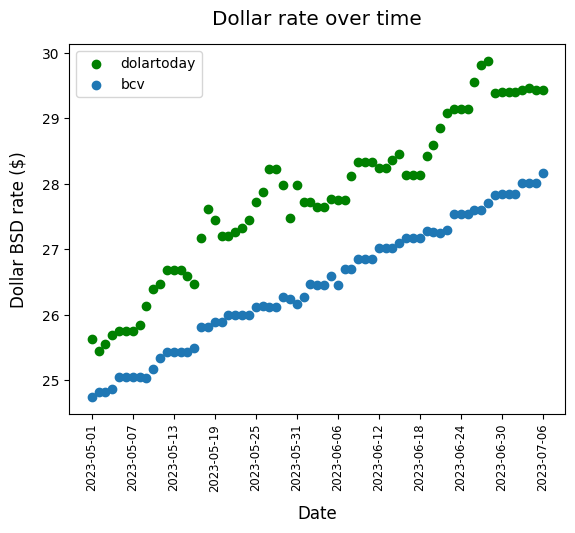

```python
# First graph (dolartoday)
plt.scatter(df["day"], df["dolartoday"], color="green", label="dolartoday")

# Second graph (bcv)
plt.scatter(df["day"], df["bcv"], label="bcv")

# graph settings
plt.title("Dollar rate over time", pad=14.0, fontsize="x-large")
plt.xlabel("Date", labelpad=10.0, fontsize="large")
plt.ylabel("Dollar BSD rate ($)", labelpad=10.0, fontsize="large")
plt.legend()

# xticks settings
num_ticks = 10
total_rows = len(df)
tick_positions = list(range(0, total_rows + 1, total_rows//num_ticks))
dates = [df["day"][i] for i in tick_positions]
plt.xticks(tick_positions, dates, rotation="vertical", fontsize="small")

plt.show()
```

## Model

Our goal is then build regression models we can use to predict future values of `bcv` and `dolartoday` for a given day. In this regard, we are going to need two separate models, one for predicting `bcv` rates and another for predicting `dolartoday` rates. In both models, the only feature variable that will be used in this project is `day`.

From the previous graph, we can see that `bcv` data very closely resembles a line, so it's a perfect candidate for a linear model. Therefore, for this model, we will use single-variable linear regression.

Dolartoday's data highly resembles a function of $f(x) = sin(g(x)) + h(x)$, where both $g$ and $h$ are linear functions. Although we can try to fit it within a linear or polynomial model, we decide that, due to its high complexity, this model will be left out of the document analysis for time being, and will be included in future updates of this project.

### Transform

Since we want to use a date (`day` column) as our only feature variable, we need to convert it into a corresponding numeric type, so we will create a new column with the date transformed into ordinal format.

```python
df["ordinal_date"] = df["day"].apply(lambda day: date.fromisoformat(day).toordinal())
print(f"This is how the days look like now (first 5 rows):\n{df['ordinal_date'].head()}")
```

```
This is how the days look like now (first 5 rows):
0    738641
1    738642
2    738643
3    738644
4    738645
Name: ordinal_date, dtype: int64
```

### Train-test split the data

Since we're working with such a small dataset, our testing data should naturally be high, but seeing as this is a simple linear model, the testing portion doesn't have to be as high. A 25% of observations allocated into testing data should suffice.

```python
from sklearn.model_selection import train_test_split
```

```python
train_df, test_df = train_test_split(df, test_size=0.25, random_state=0)
```

### Normalize (scale)

Since we're working with just a single feature variable, and our model will be linear, scaling the data is not required for a working model yielding accurate results. However, it comes handy for interpreting the function's intercept and slope later on. We will use z-score normalization.

```python
from sklearn.preprocessing import StandardScaler
```

```python
scaler = StandardScaler()
scaler.fit(train_df[["ordinal_date"]])
x_train_scaled = scaler.transform(train_df[["ordinal_date"]])
```

### Model training

We will use OLS (ordinary least squares) regression method.

```python
from sklearn.linear_model import LinearRegression
```

```python
linear_model = LinearRegression()
linear_model.fit(x_train_scaled, train_df["bcv"])
```

```
LinearRegression()
```

### Model interpretation

```python
print(f"Y axis intercept: {linear_model.intercept_}")
print(f"Slope of the line: {linear_model.coef_[0]}")
```

```
Y axis intercept: 26.369200000001864
Slope of the line: 1.0300833561174763
```

Above are shown the intercept and slope of our model's function. Our model can then be mathematically described as this linear function: $f(x) = 1.03x + 26.37$

### Model evaluation

We will use the test split data to evaluate the model's performance. We will use several error metrics to understand our model's performance. The ones we will employ will be:

- Mean Squared Error (MSE)
- Root Mean Squared Error (RMSE)
- Mean Absolute Error (MAE)
- R-Squared (R2) Score

```python
# Scale the test feature variable
x_test_scaled = scaler.transform(test_df[["ordinal_date"]])

# Compute the predicted values for our test split data
y_test_predicted = linear_model.predict(x_test_scaled)
```

```python
# MSE
from sklearn.metrics import mean_squared_error
mse = mean_squared_error(test_df["bcv"], y_test_predicted)
print(f"Mean Squared Error (MSE): {mse}")

# RMSE
import math
rmse = math.sqrt(mse)
print(f"Root Mean Squared Error (RMSE): {rmse}")

# MAE
from sklearn.metrics import mean_absolute_error
mae = mean_absolute_error(test_df["bcv"], y_test_predicted)
print(f"Mean Absolute Error (MAE): {mae}")

# R2
r2 = linear_model.score(x_train_scaled, train_df["bcv"])
print(f"R-squared (R2) score: {r2}")
```

```
Mean Squared Error (MSE): 0.0029701389066954906
Root Mean Squared Error (RMSE): 0.05449898078584122
Mean Absolute Error (MAE): 0.046460968906856484
R-squared (R2) score: 0.9927177804022459
```

This is how our model looks like.

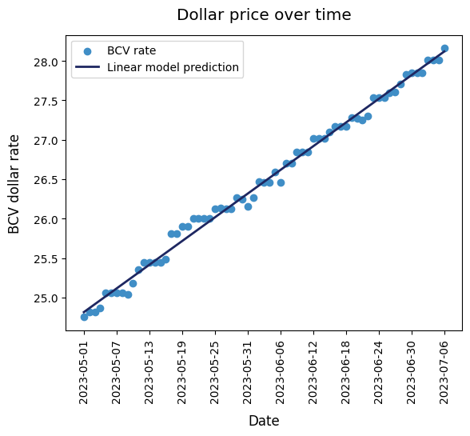

```python
# First graph
plt.scatter(
    df["day"],
    df["bcv"],
    marker="o",
    color="#408ec6",
    label="BCV rate"
)

# Second graph
x_scaled = scaler.transform(df[["ordinal_date"]])
y_predicted = linear_model.predict(x_scaled)
plt.plot(df["day"], y_predicted, linewidth=2, color="#1e2761", label="Linear model prediction")

# graph settings
num_ticks = 10
tick_positions = list(range(0, len(df)+1, len(df)//(num_ticks)))
dates = [df["day"][i] for i in tick_positions]
plt.xticks(tick_positions, dates, rotation="vertical")
plt.title("Dollar price over time", pad=14.0, fontsize="x-large")
plt.xlabel("Date", labelpad=10.0, fontsize="large")
plt.ylabel("BCV dollar rate", labelpad=10.0, fontsize="large")
plt.legend()
plt.show()
```

### August predictions

We can now use our model for the reason it was created: make future predictions about the dollar rates. We will use our linear model to predict August `bcv` dollar rates.

```python
# Get a list of all august days
august_days = []
for day_number in range(1, 32):
    day_string = str(day_number).zfill(2)
    august_day = f"2023-08-{day_string}"
    august_days.append(august_day)

# Make a dataframe
august_df = pd.DataFrame(august_days, columns=["day"])

# Get ordinal dates scaled
august_df["ordinal_date"] = august_df["day"].apply(lambda day: date.fromisoformat(day).toordinal())
x_august_scaled = scaler.transform(august_df[["ordinal_date"]])

# Predict august values
y_august = linear_model.predict(x_august_scaled)
```

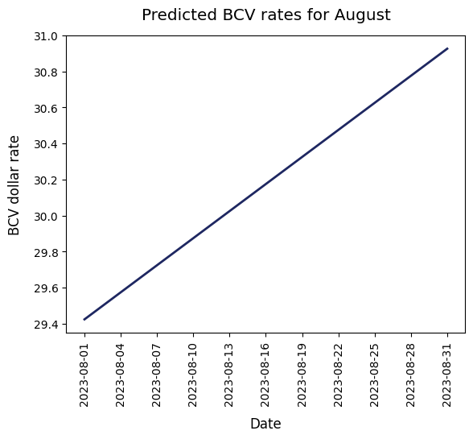

```python
# Plot
plt.plot(august_df["day"], y_august, linewidth=2, color="#1e2761")

# Graph settings
august_tick_positions = list(range(0, len(august_df) + 1, len(august_df)//(num_ticks)))
august_dates = [august_df["day"][i] for i in august_tick_positions]
plt.xticks(august_tick_positions, august_dates, rotation="vertical")
plt.title("Predicted BCV rates for August", pad=14.0, fontsize="x-large")
plt.xlabel("Date", labelpad=10.0, fontsize="large")
plt.ylabel("BCV dollar rate", labelpad=10.0, fontsize="large")
plt.show()
```

## Conclusion

We found out `bcv` rates increase over time in a pseudo linear fashion, this allowed us to take advantage of it and build an extraordinary linear model to make predictions of its value with a given day as input. We evaluated its performance and the results were amazing.

The resulting linear model follow this function: $f(x) = 1.03x + 26.37$.

Thanks to this model, we were able to predict the upcoming `bcv` rates for August.

`dolartoday` rates are more erratic and it's harder to fit this variable in the best possible model. Although a linear model could have the done the job pretty much fine, we decided to leave it for later updates.

## Extra

### Rate difference in dollars

Our first strategy will be to find the difference between `dolartoday` and `bcv` and study the distribution of this data through a kernel density estimate (KDE) plot.

```python
# Create a new column as the raw difference between the two rates
df["rates_difference_dollar"] = df["dolartoday"] - df["bcv"]
```

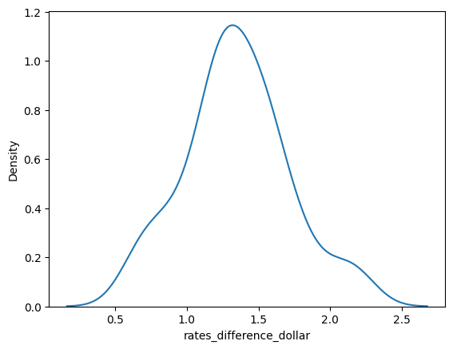

```python
import seaborn as sns
sns.kdeplot(df["rates_difference_dollar"])
```

```python
# Calculate the mean and the standard distribution
print(f"Mean of this dollar difference: {df['rates_difference_dollar'].mean()}")
print(f"Standard distribution of this difference: {df['rates_difference_dollar'].std()}")
```

```
Mean of this dollar difference: 1.3471641791044773
Standard distribution of this difference: 0.36043242534888065
```

Interestingly, the distribution of this difference between the rates follows the pattern of a normal distribution with mean around $\$1.35$ and standard deviation of $\$0.36$. So, statistically speaking, it's $68\%$ likely that the `dolartoday` of its `bcv` counterpart would be within one (1) standard deviations away from the mean, $95\%$ likely it will be two (2) standard deviations away from the mean, and so on. For example, if a `bcv` value for a day is $\$28.00$, then it's $68\%$ likely the `dolartoday` rate for that day will be in the range of $\$28.99$ and $\$29.71$.

To make sure these results are unbiased, we will plot this difference over the days.

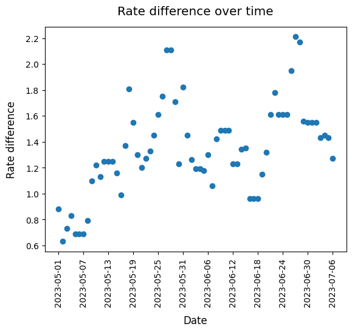

```python
plt.scatter(df["day"], df["rates_difference_dollar"])

# graph settings
plt.xticks(tick_positions, dates, rotation="vertical")
plt.title("Rate difference over time", pad=14.0, fontsize="x-large")
plt.xlabel("Date", labelpad=10.0, fontsize="large")
plt.ylabel("Rate difference", labelpad=10.0, fontsize="large")
plt.show()
```

Although erratic, if anything, there probably is an increasing tendency for this difference. If so, then our conclusions made early won't hold much ground long term, unless this data difference is re-calculated every so often to avoid inaccurate results from this method. Still, it was interesting to find this pattern and relationship between the two variables, and to find out that their difference falls in a normal distribution.

Another strategy we could've followed is to compute the difference not as a raw number, but as a ratio between `dolartoday` and `bcv`. The results wouldn't have been much different, however.